# 统计计算 Homework-9 报告

林子开 21307110161

2023年12月9日

# Exercise 9.1

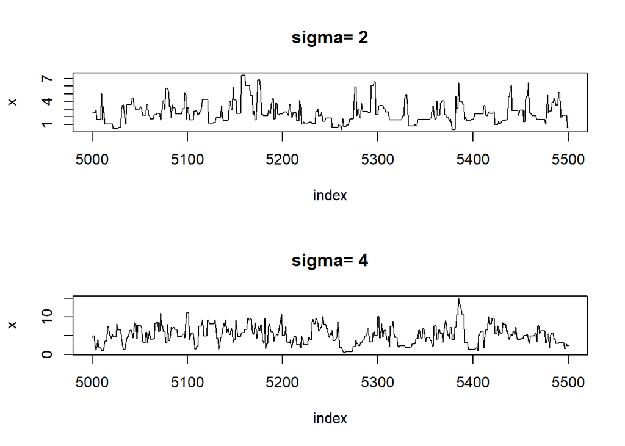

```r
# The following function evaluates the Rayleigh density
f <- function(x,sigma=2){
  if (any(x<0)) return(0)
  stopifnot(sigma > 0)
  return((x / sigma^2) * exp( -x^2 / (2*sigma^2) ) )
}

par(mfrow=c(2,1))
m <- 10000 # length of the chain
ks = numeric(2) # used to store the reject rates
sigmas = c(2,4)

for(p in 1:2){ # try different sigma in Rayleigh dist
  set.seed(123456)
  sigma = sigmas[p]
  x <- numeric(m)
  x[1] <- rchisq(1,df=1)
  k <- 0 # used to count the rejecting times
  u <- runif(m) # used in the accept/reject decision

  for(i in 2:m){
    xt <- x[i-1]
    y <- rchisq(1,df=xt) # proposal by Chi-square dist
    num <- f(y,sigma) * dchisq(xt,df=y)
    den <- f(xt,sigma) * dchisq(y,df=xt)
    if(u[i] <= num/den){ # accept
      x[i] <- y
      }
    else{ # reject
      x[i] <- xt
      k <- k+1
    }
  }
  ks[p] = (k/m) # the reject rates

  index <- 5000:5500
  x1 <- x[index]
  plot(index,x1,type='l',main=paste('sigma=',sigma),ylab='x')
}
```

```r
Table = as.data.frame(matrix(ks,nrow=1))
colnames(Table) <- c(paste('sigma=',2),paste('sigma=',4))
rownames(Table) <- c('reject rates')
print(Table)
```

```
##              sigma= 2 sigma= 4
## reject rates    0.528   0.4058
```

从图中可以看出，$\sigma=2$时，与$\sigma=4$相比，马尔科夫链中出现了**更多水平的直线**。从拒绝率上看，$\sigma=2$时的拒绝率为0.528，而$\sigma=4$时的拒绝率为0.4058，说明$\sigma=2$时的**拒绝率更高，算法的效率更低**。

# Exercise 9.2

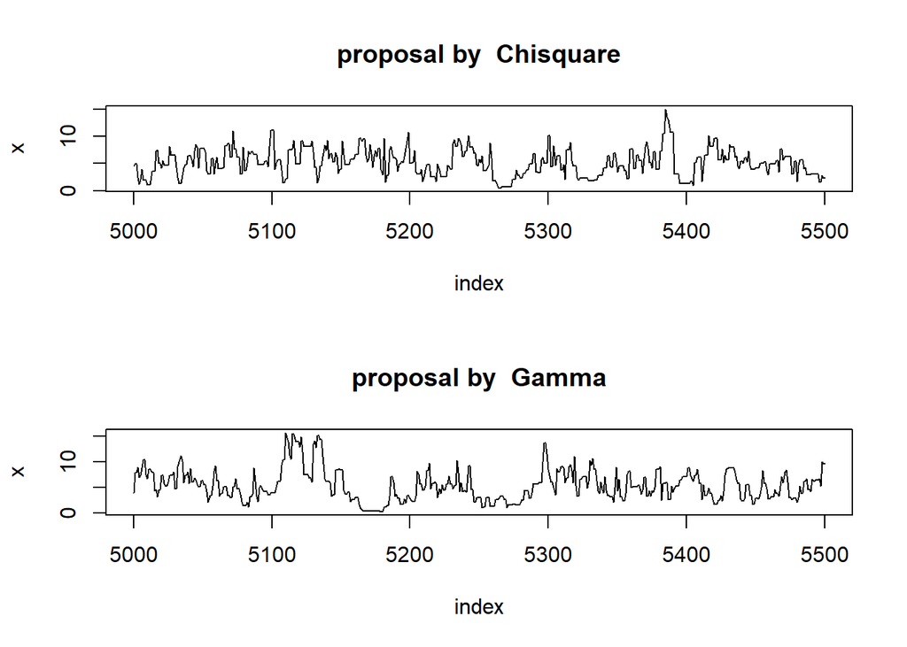

```r
# The following function evaluates the Rayleight density
f <- function(x,sigma=4){
  if (any(x<0)) return(0)
  stopifnot(sigma > 0)
  return((x / sigma^2) * exp( -x^2 / (2*sigma^2) ) )
}

par(mfrow=c(2,1))
m <- 10000
sigma <- 4
proposals = c('Chisquare','Gamma')
ks = numeric(2)

for(p in 1:2){
  set.seed(123456)
  proposal = proposals[p]
  x <- numeric(m)
  x[1] <- rchisq(1,df=1)
  k <- 0 # used for counting the rejecting times
  u <- runif(m)

  for(i in 2:m){
    xt <- x[i-1]
    if(proposal == 'Chisquare'){
      y <- rchisq(1,df=xt) # proposal by Chi-square
    }
    else{
      y <- rgamma(1,shape=xt,rate=1) # proposal by Gamma
    }
    num <- f(y,sigma) * dchisq(xt,df=y)
    den <- f(xt,sigma) * dchisq(y,df=xt)
    if(u[i] <= num/den){ # accepted
      x[i] <- y
    }
    else{ # rejected
      x[i] <- xt
      k <- k+1
    }
  }
  ks[p] = (k/m) # the reject rates

  index <- 5000:5500
  x1 <- x[index]
  plot(index,x1,type='l',main=paste('proposal by ',proposal),ylab='x')
}
```

```r
Table = as.data.frame(matrix(ks,nrow=1))
colnames(Table) <- c('Chisquare','Gamma')
rownames(Table) <- c('reject rates')
print(Table)
```

```
##              Chisquare  Gamma
## reject rates    0.4058 0.2988
```

从图中可以看出，使用卡方分布作为proposal时，与使用Gamma分布作为proposal相比，马尔科夫链中出现了**更多水平的直线**。从拒绝率上看，使用卡方分布作为proposal时的拒绝率为0.4058，而使用Gamma分布时的拒绝率为0.2988，说明使用Gamma分布作为proposal时**拒绝率更低，算法的效率更高**。

# Exercise 9.3

```r
set.seed(123)

m <- 10000
x <- numeric(m)
x[1] <- rt(1,df=10) # using student-t distribution as proposal
k <- 0
u <- runif(m)

for(i in 2:m){
  xt <- x[i-1]
  y <- rt(1,df=abs(xt)+1) # proposal by t distribution
  num <- dcauchy(y) * dt(xt,df=abs(y)+1)
  den <- dcauchy(xt) * dt(y,df=abs(xt)+1)
  if(u[i] <= num/den){ # accepted
    x[i] <- y
  }
  else{ # rejected
    x[i] <- xt
    k <- k+1
  }
}
```

```r
index <- 1001:m # discard the first 1000 of the chain
x1 <- x[index]

deciles.MC <- quantile(x1, probs=seq(0.1,0.9, by=0.1))
deciles.standard <- qcauchy(seq(0.1,0.9, by=0.1))
comparison = as.data.frame(rbind(deciles.standard,deciles.MC))
rownames(comparison) <- c('standard','MC')
print(comparison)
```

```
##                10%       20%        30%        40%        50%       60%
## standard -3.077684 -1.376382 -0.7265425 -0.3249197 0.00000000 0.3249197
## MC       -2.959869 -1.336536 -0.6964239 -0.3069642 0.01347246 0.3539134
##                70%      80%      90%
## standard 0.7265425 1.376382 3.077684
## MC       0.7580736 1.428828 3.221366
```

# Exercise 9.4

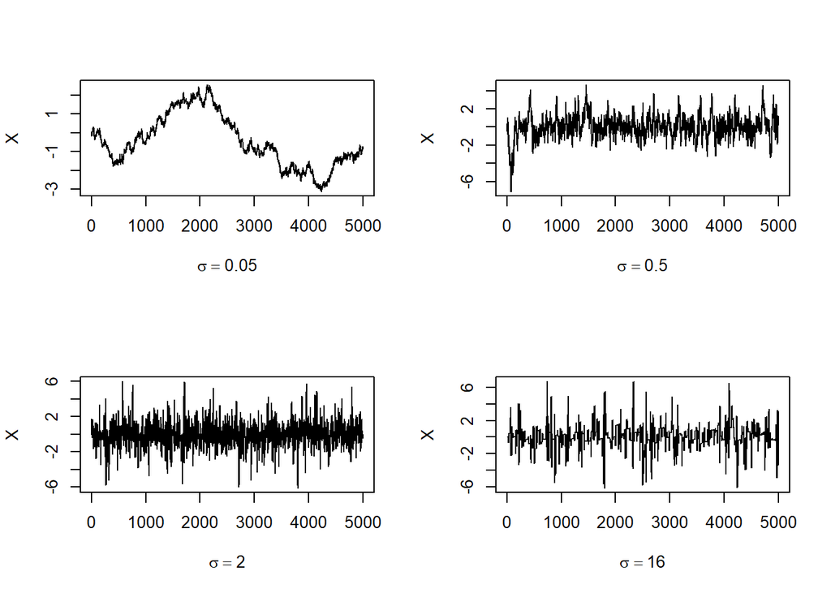

```r
# the following function evaluate the Laplace density
f <- function(x){
  return( 0.5 * exp(-abs(x)) )
}

# the following function is the random walk Metropolis sampler
RandomWalk.Metropolis <- function(sigma,x0,N){
  x <- numeric(N)
  x[1]  <- x0
  u = runif(N)
  k <- 0
  for(i in 2:N){
    y <- rnorm(1,x[i-1],sigma) # proposal by normal distribution
    if(u[i] <= f(y)/f(x[i-1])){
      x[i] <- y # accepted
    }
    else{ # rejected
      x[i] <- x[i-1]
      k <- k + 1
    }
  }
  return(list(x=x,k=k))
}

# compare the chain and acceptance rates using different variances
N <- 5000
sigma <- c(.05, .5, 2, 16)
x0 <- 0
set.seed(2023)
rw1 <- RandomWalk.Metropolis(sigma[1],x0,N)
rw2 <- RandomWalk.Metropolis(sigma[2],x0,N)
rw3 <- RandomWalk.Metropolis(sigma[3],x0,N)
rw4 <- RandomWalk.Metropolis(sigma[4],x0,N)

# compare the chain
par(mfrow=c(2,2))
rw <- cbind(rw1$x,rw2$x,rw3$x,rw4$x)
for(j in 1:4){
  plot(rw[,j],type='l',
  xlab=bquote(sigma == .(round(sigma[j],3))),
  ylab='X',ylim=range(rw[,j]) )
}
```

可以看出，当$\sigma=0.05$时，马尔科夫链在5000步前并未收敛；当$\sigma=0.5$和$\sigma=2$时，马尔科夫链都能较快地收敛；当$\sigma=16$时，可以发现图中有较多的水平直线，说明有很多样本被拒绝了，尽管此时算法收敛，但效率比较低。

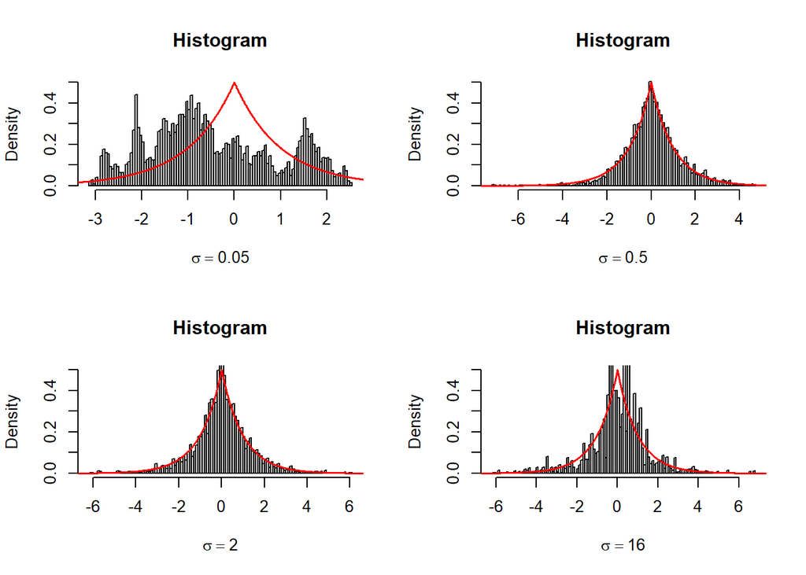

```r
# compare the histogram
par(mfrow=c(2,2))
xx <- seq(-10,10,by=0.01)
yy <- f(xx)
for(j in 1:4){
  hist(rw[,j],breaks=100,freq = F,ylim = c(0,0.5),
       xlab=bquote(sigma == .(round(sigma[j],3))),main='Histogram')
  lines(xx,yy,col='red',lwd=1.5)
}
```

可以看出，$\sigma=0.05$时，样本的经验分布和标准拉普拉斯分布并不吻合，说明算法并未收敛；当$\sigma=0.5$和$\sigma=2$时，样本的经验分布和标准拉普拉斯分布吻合，说明算法收敛；当$\sigma=16$时，样本的经验分布与标准拉普拉斯分布大致吻合，但不如$\sigma=0.5$和$\sigma=2$的吻合程度高，这也反映出算法的效率比较低。

```r
# compare the acceptance rates, the suitable interval is [0.15,0.5]
Table = 1-c(rw1$k,rw2$k,rw3$k,rw4$k)/N
Table = as.data.frame(matrix(Table,nrow=1))
rownames(Table) = c('acceptance rates')
colnames(Table) = c('sigma=0.05','sigma=0.5','sigma=2','sigma=16')
Table
```

```
##                  sigma=0.05 sigma=0.5 sigma=2 sigma=16
## acceptance rates     0.9822    0.8316  0.5156   0.1018
```

# Exercise 9.5

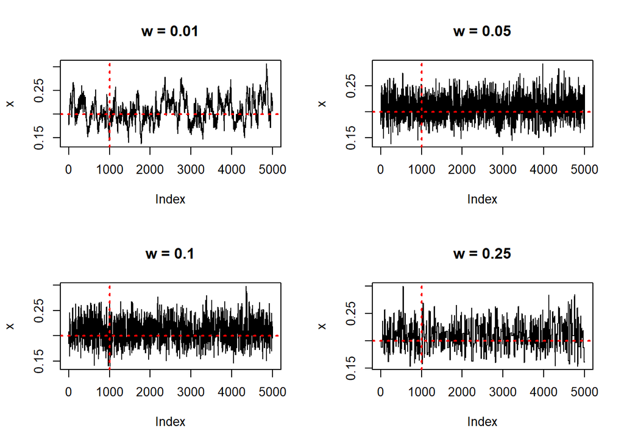

```r
set.seed(2023)

b <- 0.2 # actual value of beta
m <- 5000 # length of the chain
burn <- 1000 # burn-in time
days <- 250
x <- numeric(m) # the chain

# generate the observed frequencies of winners
i <- sample(1:5,size=days, replace=TRUE, prob=c(1,1-b,1-2*b,2*b,b))
win <- tabulate(i)

# the following function prob computes the target density
# (without the constant)
prob <- function(y,win){
  if(y < 0 || y >= 0.5)
    return(0)
  return( (1/3)^win[1] *
    ((1-y)/3)^win[2] * ((1-2*y)/3)^win[3] *
      ((2*y)/3)^win[4] * (y/3)^win[5] )
}

u <- runif(m) # for accept/reject step

X = matrix(numeric(4*m),ncol=4)
reject.rates = numeric(4)
mean.xb = numeric(4)
ws = c(0.01,0.05,0.1,0.25)
for(p in 1:4){
  set.seed(2023)
  w = ws[p]
  k <- 0
  v <- runif(m,-w,w) # proposal distribution
  x[1] <- 0.2
  for(i in 2:m){
    y <- x[i-1] + v[i]
    if (u[i] <= prob(y,win) / prob(x[i-1],win)){ # accept
      x[i] <- y}
    else{
        x[i] <- x[i-1] # reject
        k <- k+1
    }
  }
  X[,p] = x
  xb <- x[-(1:burn)]
  reject.rates[p] = k/m
  mean.xb[p] = mean(xb)
}

# plot the chain
par(mfrow=c(2,2))
for(p in 1:4){
  x = X[,p]
  plot(x,type='l',main=paste('w =',ws[p]))
  abline(h=b,v=burn,lty=3,col='red',lwd=2)
}
```

当$w=0.01$时，马尔可夫似乎无法在5000步迭代之内收敛，说明太小的$w$可能导致收敛速度太慢。$w=0.05$与$w=0.1$时，马尔可夫链都能收敛。$w=0.25$时，马尔科夫链虽然能收敛，但出现了很多水平直线，说明拒绝率比较高。

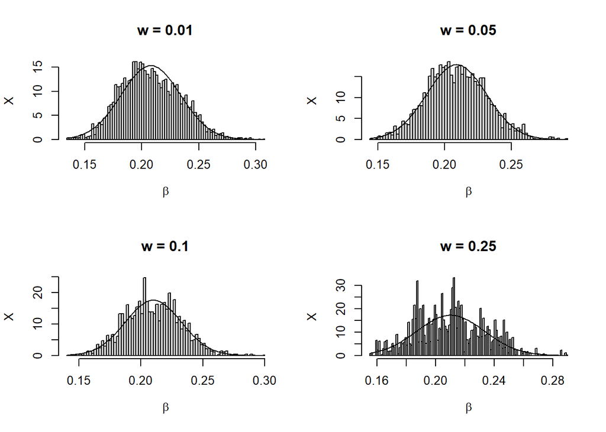

```r
# plot the histogram
par(mfrow=c(2,2))
for(p in 1:4){
  x = X[,p]
  xb <- x[-(1:burn)]
  hist(xb,freq=F,breaks =100,xlab=bquote(beta),ylab='X',main=paste('w =',ws[p]))
  z <- seq(min(xb),max(xb),length=200)
  lines(z,dnorm(z,mean(xb),sd(xb)))
}
```

```r
# show the sample mean and reject rates
Table = as.data.frame(rbind(mean.xb,reject.rates))
colnames(Table) <- c('w=0.01','w=0.05','w=0.1','w=0.25')
rownames(Table) <- c('sample mean ','reject rates ')
Table
```

```
##                  w=0.01    w=0.05     w=0.1    w=0.25
## sample mean   0.2078106 0.2088723 0.2099348 0.2101147
## reject rates  0.1032000 0.4102000 0.6408000 0.8616000
```